# When to launch a Data Science tutorial: An analysis with gtrendsR

Andrea Scalco

Recently, while browsing [R-Bloggers](https://www.r-bloggers.com/), my interest got captured by a [short review](https://www.r-bloggers.com/fundatafriday-gtrendsr/) about the [**gtrendsR**](https://cran.r-project.org/web/packages/gtrendsR/gtrendsR.pdf) package developed by P. Massicotte and D. Eddelbuettel. This R package allows retrieving and displaying information from [**Google Trends**](https://trends.google.com/trends), the website launched by Google that let you analyse users’ search queries performed trough its search engine. Needless to say, I immediately started playing with it, and **here I summarised what I learned**.

## Retrieve the data

First things first, install the package using the standard package installation method.

```r
install.packages("gtrendsR")
```

After installing, it is possible to query Google Trends and collecting some data using the function `gtrends()`. Nowadays **Data Science** seems to be a popular topic with a growing number of articles and tutorials, thus, I decided to focus on that.

```r
# Load package
library(gtrendsR)

# Choose the keyword(s) of interest
g.keywords <- c("Data science")
# Note that you can also add other keywords

# Retrieve data with function "gtrends"
my.trend <- gtrends(keyword = g.keywords,
                   geo = "",
                   time = "today+5-y")
```

Beside specific keywords, `gtrends()` gives some useful options among others worth to mention.

- `geo`: defines the location of interests (e.g. US, Europe, Italy, UK). To know the specific codes of each **location**, type `data(countries); countries`.
- `time`: a second important option is the **time span** of the query. Some options available includes `"now 7-d"` for the past seven days, `"today 12-m"` for the past 12 months, or `"Y-m-d Y-m-d"` for the time span between two dates.
- `gprop`: limits the search to specific **Google products**. “web” is the default option, however, others options include “news”, “images”, or “youtube”.

For this small project, the research was not limited to any specific country since it was assumed that the term “Data Science” has not been translated in most of the world regions. About the time span, a 5-year time framework was set in order to observe how the interest changed over years starting approximately from [the first IEEE International Conference on Data Science and Advanced Analytics](https://web.archive.org/web/20170329172857/http://datamining.it.uts.edu.au/conferences/dsaa14/). Finally, given the interest was only for web searches, the default option for Google product was left unchanged.

## Plot the trend of interest

The package manual states that `gtrends()` generates “an object of class ‘gtrends’”. This might be a tricky object to plot when in hurry since it is a list of data frames. However, the package comes with a built-in function that let you **immediately plot** the data collected using ggplot2.

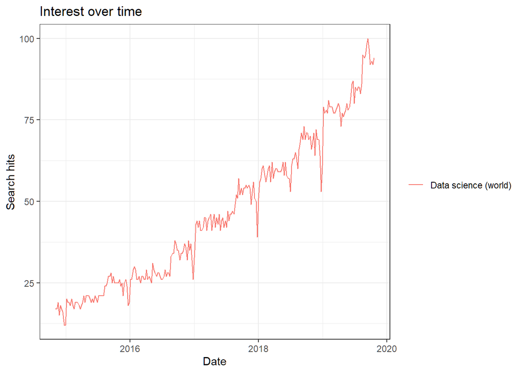

```r
plot(my.trend)
```

Nice and easy, the plot shows the interest for “Data science” from October 2014 to October 2019 as collected by Google search engine.

However, with a little more time, I managed to create **my own plot**, so that I could be free to build over it. To this purpose, I re-arrenged the most important information collected (i.e. the time stamps and the associate volume of search queries) along with the keyword under examination from the gtrend object to a brand-new dataframe.

```r
# Create tidy dataframe extracting data obtained using gtrends
data.to.plot <- data.frame(date = my.trend$interest_over_time$date,
                           hits = my.trend$interest_over_time$hits,
                           keyword = my.trend$interest_over_time$keyword)
```

ggplot2 was then used to trace the interest over the years (the plot appears rougher than the one provided by the package, but it does the job).

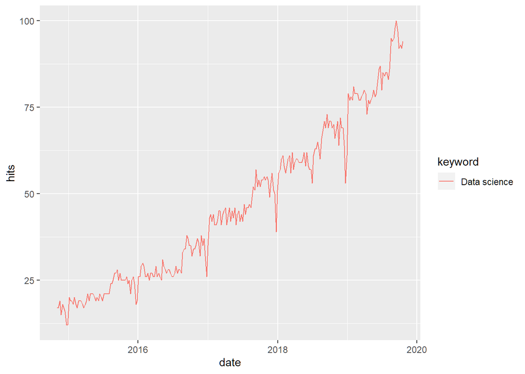

```r
# Load ggplot
library("ggplot2")

# Plot trend
ggplot(data.to.plot, aes(x = date, y = hits, color = keyword)) +
  geom_line()
```

By observing the plot, the interest for Data Science seems to be a growing trend. This appears in line with many recent articles on the topic (see especially [the report by IBM](https://www.ibm.com/downloads/cas/3RL3VXGA)). **One idea for the future** could be to refine the work by introducing **time series analysis**. A starting point might be the tutorials by A. Coghlan [(Using R for Time Series Analysis)](https://a-little-book-of-r-for-time-series.readthedocs.io/en/latest/src/timeseries.html) and by S. Prabhakaran [(Time Series Analysis at r-statistics.co)](http://r-statistics.co/Time-Series-Analysis-With-R.html).

Besides the growth, the plot seems to display a certain pattern in the search queries: it goes down and up almost at the end of the year. Could it be around Christmas? That would be something that distract almost everybody in most parts of the world. Let’s add some marks and see if the overlap the change of the trend. To quickly spot Christmas days, I will add some vertical lines on the 25th December of each year over the previous plot.

```r
# Define a vector that contains xmas days
xmas.dates <- paste("20", c(14:19), "-12-25", sep = "")
```

[figure not shown]

## Some final considerations

Nevertheless, it must be considered that the information came only from people that used Google. Although Google is [the most used search engine across the world](https://gs.statcounter.com/search-engine-market-share), results from the others search engines were not included in the analysis (for instance, [Bing](https://www.bing.com), or the more recent “green” search engine [Ecosia](https://www.ecosia.org/?c=en)). Analogously, bear in mind that this is the interest for Data Science showed by those who have access to a computer and internet, and Google Trends did not have any restriction about the location.